# Risk Factor Analysis

## Outcome Variable

**Outcome Variable:** ever_swasted

## Predictor Variables

**Intervention Variable:** mage

**Adjustment Set:**

- arm
- meducyrs
- feducyrs
- W_mhtcm
- single
- delta_meducyrs
- delta_feducyrs
- delta_W_mhtcm
- delta_single

## Stratifying Variables

The analysis was stratified on these variable(s):

- agecat
- studyid
- country

## Data Summary

| agecat | studyid | country | mage | ever_swasted | n_cell | n |
| --- | --- | --- | --- | --- | --- | --- |
| 0-24 months | ki0047075b-MAL-ED | BANGLADESH | [20-30) | 0 | 167 | 263 |
| 0-24 months | ki0047075b-MAL-ED | BANGLADESH | [20-30) | 1 | 13 | 263 |
| 0-24 months | ki0047075b-MAL-ED | BANGLADESH | <20 | 0 | 32 | 263 |
| 0-24 months | ki0047075b-MAL-ED | BANGLADESH | <20 | 1 | 5 | 263 |
| 0-24 months | ki0047075b-MAL-ED | BANGLADESH | >=30 | 0 | 43 | 263 |
| 0-24 months | ki0047075b-MAL-ED | BANGLADESH | >=30 | 1 | 3 | 263 |
| 0-24 months | ki0047075b-MAL-ED | BRAZIL | [20-30) | 0 | 138 | 233 |
| 0-24 months | ki0047075b-MAL-ED | BRAZIL | [20-30) | 1 | 1 | 233 |
| 0-24 months | ki0047075b-MAL-ED | BRAZIL | <20 | 0 | 41 | 233 |
| 0-24 months | ki0047075b-MAL-ED | BRAZIL | <20 | 1 | 2 | 233 |
| 0-24 months | ki0047075b-MAL-ED | BRAZIL | >=30 | 0 | 50 | 233 |
| 0-24 months | ki0047075b-MAL-ED | BRAZIL | >=30 | 1 | 1 | 233 |
| 0-24 months | ki0047075b-MAL-ED | INDIA | [20-30) | 0 | 175 | 249 |
| 0-24 months | ki0047075b-MAL-ED | INDIA | [20-30) | 1 | 19 | 249 |
| 0-24 months | ki0047075b-MAL-ED | INDIA | <20 | 0 | 31 | 249 |
| 0-24 months | ki0047075b-MAL-ED | INDIA | <20 | 1 | 3 | 249 |
| 0-24 months | ki0047075b-MAL-ED | INDIA | >=30 | 0 | 19 | 249 |
| 0-24 months | ki0047075b-MAL-ED | INDIA | >=30 | 1 | 2 | 249 |
| 0-24 months | ki0047075b-MAL-ED | NEPAL | [20-30) | 0 | 180 | 240 |
| 0-24 months | ki0047075b-MAL-ED | NEPAL | [20-30) | 1 | 9 | 240 |
| 0-24 months | ki0047075b-MAL-ED | NEPAL | <20 | 0 | 5 | 240 |
| 0-24 months | ki0047075b-MAL-ED | NEPAL | <20 | 1 | 0 | 240 |
| 0-24 months | ki0047075b-MAL-ED | NEPAL | >=30 | 0 | 46 | 240 |
| 0-24 months | ki0047075b-MAL-ED | NEPAL | >=30 | 1 | 0 | 240 |
| 0-24 months | ki0047075b-MAL-ED | PERU | [20-30) | 0 | 151 | 302 |
| 0-24 months | ki0047075b-MAL-ED | PERU | [20-30) | 1 | 2 | 302 |
| 0-24 months | ki0047075b-MAL-ED | PERU | <20 | 0 | 81 | 302 |
| 0-24 months | ki0047075b-MAL-ED | PERU | <20 | 1 | 1 | 302 |
| 0-24 months | ki0047075b-MAL-ED | PERU | >=30 | 0 | 67 | 302 |
| 0-24 months | ki0047075b-MAL-ED | PERU | >=30 | 1 | 0 | 302 |

[output cut: 450 more lines]

The following strata were considered:

- agecat: 0-24 months, studyid: ki0047075b-MAL-ED, country: BANGLADESH
- agecat: 0-24 months, studyid: ki0047075b-MAL-ED, country: BRAZIL
- agecat: 0-24 months, studyid: ki0047075b-MAL-ED, country: INDIA
- agecat: 0-24 months, studyid: ki0047075b-MAL-ED, country: NEPAL
- agecat: 0-24 months, studyid: ki0047075b-MAL-ED, country: PERU
- agecat: 0-24 months, studyid: ki0047075b-MAL-ED, country: SOUTH AFRICA
- agecat: 0-24 months, studyid: ki0047075b-MAL-ED, country: TANZANIA, UNITED REPUBLIC OF
- agecat: 0-24 months, studyid: ki1000108-CMC-V-BCS-2002, country: INDIA
- agecat: 0-24 months, studyid: ki1000108-IRC, country: INDIA
- agecat: 0-24 months, studyid: ki1000109-EE, country: PAKISTAN
- agecat: 0-24 months, studyid: ki1000304b-SAS-CompFeed, country: INDIA
- agecat: 0-24 months, studyid: ki1000304b-SAS-FoodSuppl, country: INDIA
- agecat: 0-24 months, studyid: ki1017093-NIH-Birth, country: BANGLADESH
- agecat: 0-24 months, studyid: ki1017093b-PROVIDE, country: BANGLADESH
- agecat: 0-24 months, studyid: ki1017093c-NIH-Crypto, country: BANGLADESH
- agecat: 0-24 months, studyid: ki1066203-TanzaniaChild2, country: TANZANIA, UNITED REPUBLIC OF
- agecat: 0-24 months, studyid: ki1101329-Keneba, country: GAMBIA
- agecat: 0-24 months, studyid: ki1112895-Guatemala BSC, country: GUATEMALA
- agecat: 0-24 months, studyid: ki1112895-iLiNS-Zinc, country: BURKINA FASO
- agecat: 0-24 months, studyid: ki1113344-GMS-Nepal, country: NEPAL
- agecat: 0-24 months, studyid: ki1119695-PROBIT, country: BELARUS
- agecat: 0-24 months, studyid: ki1126311-ZVITAMBO, country: ZIMBABWE
- agecat: 0-24 months, studyid: ki1135781-COHORTS, country: GUATEMALA
- agecat: 0-24 months, studyid: ki1135781-COHORTS, country: INDIA
- agecat: 0-24 months, studyid: ki1135781-COHORTS, country: PHILIPPINES
- agecat: 0-24 months, studyid: ki1148112-LCNI-5, country: MALAWI
- agecat: 0-24 months, studyid: kiGH5241-JiVitA-3, country: BANGLADESH
- agecat: 0-6 months, studyid: ki0047075b-MAL-ED, country: BANGLADESH
- agecat: 0-6 months, studyid: ki0047075b-MAL-ED, country: BRAZIL
- agecat: 0-6 months, studyid: ki0047075b-MAL-ED, country: INDIA
- agecat: 0-6 months, studyid: ki0047075b-MAL-ED, country: NEPAL
- agecat: 0-6 months, studyid: ki0047075b-MAL-ED, country: PERU
- agecat: 0-6 months, studyid: ki0047075b-MAL-ED, country: SOUTH AFRICA
- agecat: 0-6 months, studyid: ki0047075b-MAL-ED, country: TANZANIA, UNITED REPUBLIC OF
- agecat: 0-6 months, studyid: ki1000108-CMC-V-BCS-2002, country: INDIA
- agecat: 0-6 months, studyid: ki1000108-IRC, country: INDIA
- agecat: 0-6 months, studyid: ki1000109-EE, country: PAKISTAN
- agecat: 0-6 months, studyid: ki1000304b-SAS-CompFeed, country: INDIA
- agecat: 0-6 months, studyid: ki1000304b-SAS-FoodSuppl, country: INDIA
- agecat: 0-6 months, studyid: ki1017093-NIH-Birth, country: BANGLADESH
- agecat: 0-6 months, studyid: ki1017093b-PROVIDE, country: BANGLADESH
- agecat: 0-6 months, studyid: ki1017093c-NIH-Crypto, country: BANGLADESH
- agecat: 0-6 months, studyid: ki1066203-TanzaniaChild2, country: TANZANIA, UNITED REPUBLIC OF
- agecat: 0-6 months, studyid: ki1101329-Keneba, country: GAMBIA
- agecat: 0-6 months, studyid: ki1112895-Guatemala BSC, country: GUATEMALA
- agecat: 0-6 months, studyid: ki1113344-GMS-Nepal, country: NEPAL
- agecat: 0-6 months, studyid: ki1119695-PROBIT, country: BELARUS
- agecat: 0-6 months, studyid: ki1126311-ZVITAMBO, country: ZIMBABWE
- agecat: 0-6 months, studyid: ki1135781-COHORTS, country: GUATEMALA
- agecat: 0-6 months, studyid: ki1135781-COHORTS, country: INDIA
- agecat: 0-6 months, studyid: ki1135781-COHORTS, country: PHILIPPINES
- agecat: 0-6 months, studyid: ki1148112-LCNI-5, country: MALAWI
- agecat: 0-6 months, studyid: kiGH5241-JiVitA-3, country: BANGLADESH
- agecat: 6-24 months, studyid: ki0047075b-MAL-ED, country: BANGLADESH
- agecat: 6-24 months, studyid: ki0047075b-MAL-ED, country: BRAZIL
- agecat: 6-24 months, studyid: ki0047075b-MAL-ED, country: INDIA
- agecat: 6-24 months, studyid: ki0047075b-MAL-ED, country: NEPAL
- agecat: 6-24 months, studyid: ki0047075b-MAL-ED, country: PERU
- agecat: 6-24 months, studyid: ki0047075b-MAL-ED, country: SOUTH AFRICA
- agecat: 6-24 months, studyid: ki0047075b-MAL-ED, country: TANZANIA, UNITED REPUBLIC OF
- agecat: 6-24 months, studyid: ki1000108-CMC-V-BCS-2002, country: INDIA
- agecat: 6-24 months, studyid: ki1000108-IRC, country: INDIA
- agecat: 6-24 months, studyid: ki1000109-EE, country: PAKISTAN
- agecat: 6-24 months, studyid: ki1000304b-SAS-CompFeed, country: INDIA
- agecat: 6-24 months, studyid: ki1000304b-SAS-FoodSuppl, country: INDIA
- agecat: 6-24 months, studyid: ki1017093-NIH-Birth, country: BANGLADESH
- agecat: 6-24 months, studyid: ki1017093b-PROVIDE, country: BANGLADESH
- agecat: 6-24 months, studyid: ki1017093c-NIH-Crypto, country: BANGLADESH
- agecat: 6-24 months, studyid: ki1066203-TanzaniaChild2, country: TANZANIA, UNITED REPUBLIC OF
- agecat: 6-24 months, studyid: ki1101329-Keneba, country: GAMBIA
- agecat: 6-24 months, studyid: ki1112895-Guatemala BSC, country: GUATEMALA
- agecat: 6-24 months, studyid: ki1112895-iLiNS-Zinc, country: BURKINA FASO
- agecat: 6-24 months, studyid: ki1113344-GMS-Nepal, country: NEPAL
- agecat: 6-24 months, studyid: ki1119695-PROBIT, country: BELARUS
- agecat: 6-24 months, studyid: ki1126311-ZVITAMBO, country: ZIMBABWE
- agecat: 6-24 months, studyid: ki1135781-COHORTS, country: GUATEMALA
- agecat: 6-24 months, studyid: ki1135781-COHORTS, country: INDIA
- agecat: 6-24 months, studyid: ki1135781-COHORTS, country: PHILIPPINES
- agecat: 6-24 months, studyid: ki1148112-LCNI-5, country: MALAWI
- agecat: 6-24 months, studyid: kiGH5241-JiVitA-3, country: BANGLADESH

### Dropped Strata

Some strata were dropped due to rare outcomes:

- agecat: 0-24 months, studyid: ki0047075b-MAL-ED, country: BANGLADESH
- agecat: 0-24 months, studyid: ki0047075b-MAL-ED, country: BRAZIL
- agecat: 0-24 months, studyid: ki0047075b-MAL-ED, country: INDIA
- agecat: 0-24 months, studyid: ki0047075b-MAL-ED, country: NEPAL
- agecat: 0-24 months, studyid: ki0047075b-MAL-ED, country: PERU
- agecat: 0-24 months, studyid: ki0047075b-MAL-ED, country: SOUTH AFRICA
- agecat: 0-24 months, studyid: ki0047075b-MAL-ED, country: TANZANIA, UNITED REPUBLIC OF
- agecat: 0-24 months, studyid: ki1000109-EE, country: PAKISTAN
- agecat: 0-24 months, studyid: ki1000304b-SAS-FoodSuppl, country: INDIA
- agecat: 0-24 months, studyid: ki1017093b-PROVIDE, country: BANGLADESH
- agecat: 0-24 months, studyid: ki1112895-Guatemala BSC, country: GUATEMALA
- agecat: 0-24 months, studyid: ki1148112-LCNI-5, country: MALAWI
- agecat: 0-6 months, studyid: ki0047075b-MAL-ED, country: BANGLADESH
- agecat: 0-6 months, studyid: ki0047075b-MAL-ED, country: BRAZIL
- agecat: 0-6 months, studyid: ki0047075b-MAL-ED, country: INDIA
- agecat: 0-6 months, studyid: ki0047075b-MAL-ED, country: NEPAL
- agecat: 0-6 months, studyid: ki0047075b-MAL-ED, country: PERU
- agecat: 0-6 months, studyid: ki0047075b-MAL-ED, country: SOUTH AFRICA
- agecat: 0-6 months, studyid: ki0047075b-MAL-ED, country: TANZANIA, UNITED REPUBLIC OF
- agecat: 0-6 months, studyid: ki1000109-EE, country: PAKISTAN
- agecat: 0-6 months, studyid: ki1000304b-SAS-FoodSuppl, country: INDIA
- agecat: 0-6 months, studyid: ki1017093b-PROVIDE, country: BANGLADESH
- agecat: 0-6 months, studyid: ki1112895-Guatemala BSC, country: GUATEMALA
- agecat: 0-6 months, studyid: ki1148112-LCNI-5, country: MALAWI
- agecat: 6-24 months, studyid: ki0047075b-MAL-ED, country: BANGLADESH
- agecat: 6-24 months, studyid: ki0047075b-MAL-ED, country: BRAZIL
- agecat: 6-24 months, studyid: ki0047075b-MAL-ED, country: INDIA
- agecat: 6-24 months, studyid: ki0047075b-MAL-ED, country: NEPAL
- agecat: 6-24 months, studyid: ki0047075b-MAL-ED, country: PERU
- agecat: 6-24 months, studyid: ki0047075b-MAL-ED, country: SOUTH AFRICA
- agecat: 6-24 months, studyid: ki0047075b-MAL-ED, country: TANZANIA, UNITED REPUBLIC OF
- agecat: 6-24 months, studyid: ki1000108-CMC-V-BCS-2002, country: INDIA
- agecat: 6-24 months, studyid: ki1000108-IRC, country: INDIA
- agecat: 6-24 months, studyid: ki1000109-EE, country: PAKISTAN
- agecat: 6-24 months, studyid: ki1000304b-SAS-FoodSuppl, country: INDIA
- agecat: 6-24 months, studyid: ki1017093-NIH-Birth, country: BANGLADESH
- agecat: 6-24 months, studyid: ki1017093b-PROVIDE, country: BANGLADESH
- agecat: 6-24 months, studyid: ki1017093c-NIH-Crypto, country: BANGLADESH
- agecat: 6-24 months, studyid: ki1112895-Guatemala BSC, country: GUATEMALA
- agecat: 6-24 months, studyid: ki1119695-PROBIT, country: BELARUS
- agecat: 6-24 months, studyid: ki1148112-LCNI-5, country: MALAWI

## Methods Detail

We’re interested in the causal parameters $E[Y_a]$ for all values of $a \in \mathcal{A}$. These parameters represent the mean outcome if, possibly contrary to fact, we intervened to set all units to have $A=a$. Under the randomization and positivity assumptions, these are identified by the statistical parameters $\psi_a=E_W[E_{Y|A,W}(Y|A=a,W)]$. In addition, we’re interested in the mean of $Y$, $E[Y]$ under no intervention (the observed mean). We will estimate these parameters by using SuperLearner to fit the relevant likelihood factors – $E_{Y|A,W}(Y|A=a,W)$ and $p(A=a|W)$, and then updating our likelihood fit using a joint TMLE.

For unadjusted analyses ($W=\{\}$), initial likelihoods were estimated using Lrnr_glm to estimate the simple $E(Y|A)$ and Lrnr_mean to estimate $p(A)$. For adjusted analyses, a small library containing Lrnr_glmnet, Lrnr_xgboost, and Lrnr_mean was used.

Having estimated these parameters, we will then use the delta method to estimate relative risks and attributable risks relative to a prespecified baseline level of $A$.

# Results Detail

## Results Plots

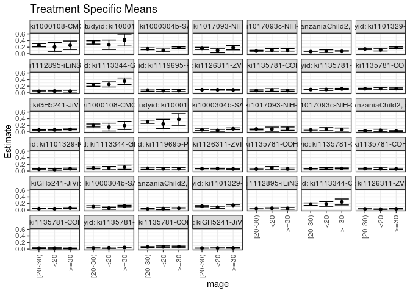

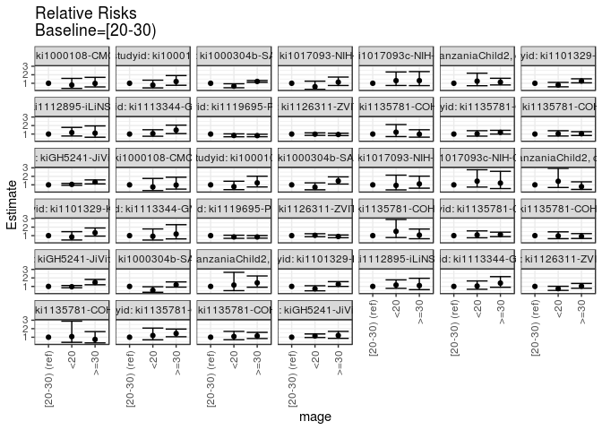

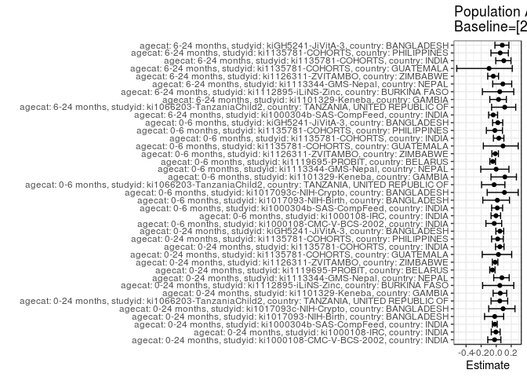

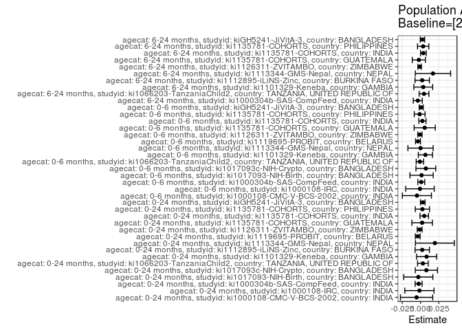

## Results Table

### Parameter: TSM

| agecat | studyid | country | intervention_level | baseline_level | estimate | ci_lower | ci_upper |
| --- | --- | --- | --- | --- | --- | --- | --- |
| 0-24 months | ki1000108-CMC-V-BCS-2002 | INDIA | [20-30) | NA | 0.2601351 | 0.2100901 | 0.3101802 |
| 0-24 months | ki1000108-CMC-V-BCS-2002 | INDIA | <20 | NA | 0.2058824 | 0.0697869 | 0.3419778 |
| 0-24 months | ki1000108-CMC-V-BCS-2002 | INDIA | >=30 | NA | 0.2558140 | 0.1252270 | 0.3864009 |
| 0-24 months | ki1000108-IRC | INDIA | [20-30) | NA | 0.3430233 | 0.2927964 | 0.3932501 |
| 0-24 months | ki1000108-IRC | INDIA | <20 | NA | 0.2702703 | 0.1269995 | 0.4135411 |
| 0-24 months | ki1000108-IRC | INDIA | >=30 | NA | 0.4137931 | 0.2343212 | 0.5932650 |
| 0-24 months | ki1000304b-SAS-CompFeed | INDIA | [20-30) | NA | 0.1500431 | 0.1201652 | 0.1799210 |
| 0-24 months | ki1000304b-SAS-CompFeed | INDIA | <20 | NA | 0.1002234 | 0.0567526 | 0.1436943 |
| 0-24 months | ki1000304b-SAS-CompFeed | INDIA | >=30 | NA | 0.1825615 | 0.1559358 | 0.2091872 |
| 0-24 months | ki1017093-NIH-Birth | BANGLADESH | [20-30) | NA | 0.1606715 | 0.1253966 | 0.1959463 |
| 0-24 months | ki1017093-NIH-Birth | BANGLADESH | <20 | NA | 0.0958904 | 0.0282924 | 0.1634885 |
| 0-24 months | ki1017093-NIH-Birth | BANGLADESH | >=30 | NA | 0.1818182 | 0.1159684 | 0.2476679 |
| 0-24 months | ki1017093c-NIH-Crypto | BANGLADESH | [20-30) | NA | 0.0790804 | 0.0552864 | 0.1028744 |
| 0-24 months | ki1017093c-NIH-Crypto | BANGLADESH | <20 | NA | 0.1035970 | 0.0527411 | 0.1544529 |
| 0-24 months | ki1017093c-NIH-Crypto | BANGLADESH | >=30 | NA | 0.1035316 | 0.0505616 | 0.1565015 |
| 0-24 months | ki1066203-TanzaniaChild2 | TANZANIA, UNITED REPUBLIC OF | [20-30) | NA | 0.0628627 | 0.0508355 | 0.0748898 |
| 0-24 months | ki1066203-TanzaniaChild2 | TANZANIA, UNITED REPUBLIC OF | <20 | NA | 0.0784842 | 0.0372211 | 0.1197474 |
| 0-24 months | ki1066203-TanzaniaChild2 | TANZANIA, UNITED REPUBLIC OF | >=30 | NA | 0.0709975 | 0.0510648 | 0.0909302 |
| 0-24 months | ki1101329-Keneba | GAMBIA | [20-30) | NA | 0.1443672 | 0.1256184 | 0.1631159 |
| 0-24 months | ki1101329-Keneba | GAMBIA | <20 | NA | 0.1156816 | 0.0820050 | 0.1493581 |
| 0-24 months | ki1101329-Keneba | GAMBIA | >=30 | NA | 0.1828210 | 0.1583838 | 0.2072582 |
| 0-24 months | ki1112895-iLiNS-Zinc | BURKINA FASO | [20-30) | NA | 0.0448886 | 0.0315695 | 0.0582077 |
| 0-24 months | ki1112895-iLiNS-Zinc | BURKINA FASO | <20 | NA | 0.0526893 | 0.0357445 | 0.0696340 |
| 0-24 months | ki1112895-iLiNS-Zinc | BURKINA FASO | >=30 | NA | 0.0496882 | 0.0240423 | 0.0753342 |
| 0-24 months | ki1113344-GMS-Nepal | NEPAL | [20-30) | NA | 0.2395249 | 0.1969435 | 0.2821062 |
| 0-24 months | ki1113344-GMS-Nepal | NEPAL | <20 | NA | 0.2529028 | 0.1751769 | 0.3306288 |
| 0-24 months | ki1113344-GMS-Nepal | NEPAL | >=30 | NA | 0.3516490 | 0.2531433 | 0.4501546 |
| 0-24 months | ki1119695-PROBIT | BELARUS | [20-30) | NA | 0.0813330 | 0.0470168 | 0.1156491 |
| 0-24 months | ki1119695-PROBIT | BELARUS | <20 | NA | 0.0677959 | 0.0379209 | 0.0976708 |
| 0-24 months | ki1119695-PROBIT | BELARUS | >=30 | NA | 0.0666714 | 0.0368823 | 0.0964605 |

[output cut: 87 more lines]

### Parameter: E(Y)

| agecat | studyid | country | intervention_level | baseline_level | estimate | ci_lower | ci_upper |
| --- | --- | --- | --- | --- | --- | --- | --- |
| 0-24 months | ki1000108-CMC-V-BCS-2002 | INDIA | NA | NA | 0.2546917 | 0.2104174 | 0.2989660 |
| 0-24 months | ki1000108-IRC | INDIA | NA | NA | 0.3414634 | 0.2955068 | 0.3874201 |
| 0-24 months | ki1000304b-SAS-CompFeed | INDIA | NA | NA | 0.1473893 | 0.1184132 | 0.1763654 |
| 0-24 months | ki1017093-NIH-Birth | BANGLADESH | NA | NA | 0.1575563 | 0.1289019 | 0.1862106 |
| 0-24 months | ki1017093c-NIH-Crypto | BANGLADESH | NA | NA | 0.0870712 | 0.0669870 | 0.1071555 |
| 0-24 months | ki1066203-TanzaniaChild2 | TANZANIA, UNITED REPUBLIC OF | NA | NA | 0.0660774 | 0.0560867 | 0.0760682 |
| 0-24 months | ki1101329-Keneba | GAMBIA | NA | NA | 0.1526371 | 0.1394613 | 0.1658129 |
| 0-24 months | ki1112895-iLiNS-Zinc | BURKINA FASO | NA | NA | 0.0471995 | 0.0353423 | 0.0590567 |
| 0-24 months | ki1113344-GMS-Nepal | NEPAL | NA | NA | 0.2591362 | 0.2241059 | 0.2941665 |
| 0-24 months | ki1119695-PROBIT | BELARUS | NA | NA | 0.0774648 | 0.0450418 | 0.1098878 |
| 0-24 months | ki1126311-ZVITAMBO | ZIMBABWE | NA | NA | 0.0912884 | 0.0865003 | 0.0960765 |
| 0-24 months | ki1135781-COHORTS | GUATEMALA | NA | NA | 0.0723341 | 0.0584645 | 0.0862036 |
| 0-24 months | ki1135781-COHORTS | INDIA | NA | NA | 0.1031103 | 0.0949263 | 0.1112943 |
| 0-24 months | ki1135781-COHORTS | PHILIPPINES | NA | NA | 0.1254516 | 0.1136848 | 0.1372183 |
| 0-24 months | kiGH5241-JiVitA-3 | BANGLADESH | NA | NA | 0.0609299 | 0.0574570 | 0.0644028 |
| 0-6 months | ki1000108-CMC-V-BCS-2002 | INDIA | NA | NA | 0.1902174 | 0.1500638 | 0.2303710 |
| 0-6 months | ki1000108-IRC | INDIA | NA | NA | 0.3073171 | 0.2626027 | 0.3520314 |
| 0-6 months | ki1000304b-SAS-CompFeed | INDIA | NA | NA | 0.0664452 | 0.0425975 | 0.0902929 |
| 0-6 months | ki1017093-NIH-Birth | BANGLADESH | NA | NA | 0.0903226 | 0.0677415 | 0.1129037 |
| 0-6 months | ki1017093c-NIH-Crypto | BANGLADESH | NA | NA | 0.0659631 | 0.0482810 | 0.0836451 |
| 0-6 months | ki1066203-TanzaniaChild2 | TANZANIA, UNITED REPUBLIC OF | NA | NA | 0.0328283 | 0.0256620 | 0.0399945 |
| 0-6 months | ki1101329-Keneba | GAMBIA | NA | NA | 0.0575569 | 0.0482661 | 0.0668478 |
| 0-6 months | ki1113344-GMS-Nepal | NEPAL | NA | NA | 0.0930233 | 0.0698010 | 0.1162455 |
| 0-6 months | ki1119695-PROBIT | BELARUS | NA | NA | 0.0760580 | 0.0435003 | 0.1086157 |
| 0-6 months | ki1126311-ZVITAMBO | ZIMBABWE | NA | NA | 0.0684336 | 0.0642223 | 0.0726450 |
| 0-6 months | ki1135781-COHORTS | GUATEMALA | NA | NA | 0.0630292 | 0.0484135 | 0.0776449 |
| 0-6 months | ki1135781-COHORTS | INDIA | NA | NA | 0.0713446 | 0.0642809 | 0.0784082 |
| 0-6 months | ki1135781-COHORTS | PHILIPPINES | NA | NA | 0.0693167 | 0.0602923 | 0.0783411 |
| 0-6 months | kiGH5241-JiVitA-3 | BANGLADESH | NA | NA | 0.0413005 | 0.0383253 | 0.0442756 |
| 6-24 months | ki1000304b-SAS-CompFeed | INDIA | NA | NA | 0.0964723 | 0.0729872 | 0.1199573 |
| 6-24 months | ki1066203-TanzaniaChild2 | TANZANIA, UNITED REPUBLIC OF | NA | NA | 0.0414378 | 0.0327076 | 0.0501681 |
| 6-24 months | ki1101329-Keneba | GAMBIA | NA | NA | 0.1178877 | 0.1056970 | 0.1300784 |
| 6-24 months | ki1112895-iLiNS-Zinc | BURKINA FASO | NA | NA | 0.0471995 | 0.0353423 | 0.0590567 |
| 6-24 months | ki1113344-GMS-Nepal | NEPAL | NA | NA | 0.1915254 | 0.1597467 | 0.2233042 |
| 6-24 months | ki1126311-ZVITAMBO | ZIMBABWE | NA | NA | 0.0325272 | 0.0291608 | 0.0358936 |
| 6-24 months | ki1135781-COHORTS | GUATEMALA | NA | NA | 0.0247321 | 0.0159885 | 0.0334756 |
| 6-24 months | ki1135781-COHORTS | INDIA | NA | NA | 0.0381279 | 0.0327962 | 0.0434596 |
| 6-24 months | ki1135781-COHORTS | PHILIPPINES | NA | NA | 0.0669277 | 0.0576848 | 0.0761707 |
| 6-24 months | kiGH5241-JiVitA-3 | BANGLADESH | NA | NA | 0.0319223 | 0.0290352 | 0.0348093 |

### Parameter: RR

| agecat | studyid | country | intervention_level | baseline_level | estimate | ci_lower | ci_upper |
| --- | --- | --- | --- | --- | --- | --- | --- |
| 0-24 months | ki1000108-CMC-V-BCS-2002 | INDIA | [20-30) | [20-30) | 1.0000000 | 1.0000000 | 1.0000000 |
| 0-24 months | ki1000108-CMC-V-BCS-2002 | INDIA | <20 | [20-30) | 0.7914439 | 0.3975810 | 1.5754863 |
| 0-24 months | ki1000108-CMC-V-BCS-2002 | INDIA | >=30 | [20-30) | 0.9833887 | 0.5699112 | 1.6968491 |
| 0-24 months | ki1000108-IRC | INDIA | [20-30) | [20-30) | 1.0000000 | 1.0000000 | 1.0000000 |
| 0-24 months | ki1000108-IRC | INDIA | <20 | [20-30) | 0.7879066 | 0.4546040 | 1.3655769 |
| 0-24 months | ki1000108-IRC | INDIA | >=30 | [20-30) | 1.2063121 | 0.7632228 | 1.9066372 |
| 0-24 months | ki1000304b-SAS-CompFeed | INDIA | [20-30) | [20-30) | 1.0000000 | 1.0000000 | 1.0000000 |
| 0-24 months | ki1000304b-SAS-CompFeed | INDIA | <20 | [20-30) | 0.6679644 | 0.4724568 | 0.9443751 |
| 0-24 months | ki1000304b-SAS-CompFeed | INDIA | >=30 | [20-30) | 1.2167268 | 1.1148178 | 1.3279517 |
| 0-24 months | ki1017093-NIH-Birth | BANGLADESH | [20-30) | [20-30) | 1.0000000 | 1.0000000 | 1.0000000 |
| 0-24 months | ki1017093-NIH-Birth | BANGLADESH | <20 | [20-30) | 0.5968105 | 0.2852176 | 1.2488106 |
| 0-24 months | ki1017093-NIH-Birth | BANGLADESH | >=30 | [20-30) | 1.1316147 | 0.7409103 | 1.7283493 |
| 0-24 months | ki1017093c-NIH-Crypto | BANGLADESH | [20-30) | [20-30) | 1.0000000 | 1.0000000 | 1.0000000 |
| 0-24 months | ki1017093c-NIH-Crypto | BANGLADESH | <20 | [20-30) | 1.3100214 | 0.7370230 | 2.3284970 |
| 0-24 months | ki1017093c-NIH-Crypto | BANGLADESH | >=30 | [20-30) | 1.3091943 | 0.7229990 | 2.3706668 |
| 0-24 months | ki1066203-TanzaniaChild2 | TANZANIA, UNITED REPUBLIC OF | [20-30) | [20-30) | 1.0000000 | 1.0000000 | 1.0000000 |
| 0-24 months | ki1066203-TanzaniaChild2 | TANZANIA, UNITED REPUBLIC OF | <20 | [20-30) | 1.2485029 | 0.7135277 | 2.1845817 |
| 0-24 months | ki1066203-TanzaniaChild2 | TANZANIA, UNITED REPUBLIC OF | >=30 | [20-30) | 1.1294066 | 0.8041622 | 1.5861965 |
| 0-24 months | ki1101329-Keneba | GAMBIA | [20-30) | [20-30) | 1.0000000 | 1.0000000 | 1.0000000 |
| 0-24 months | ki1101329-Keneba | GAMBIA | <20 | [20-30) | 0.8013010 | 0.5825881 | 1.1021223 |
| 0-24 months | ki1101329-Keneba | GAMBIA | >=30 | [20-30) | 1.2663612 | 1.0510831 | 1.5257315 |
| 0-24 months | ki1112895-iLiNS-Zinc | BURKINA FASO | [20-30) | [20-30) | 1.0000000 | 1.0000000 | 1.0000000 |
| 0-24 months | ki1112895-iLiNS-Zinc | BURKINA FASO | <20 | [20-30) | 1.1737775 | 0.7723814 | 1.7837739 |
| 0-24 months | ki1112895-iLiNS-Zinc | BURKINA FASO | >=30 | [20-30) | 1.1069228 | 0.6252556 | 1.9596433 |
| 0-24 months | ki1113344-GMS-Nepal | NEPAL | [20-30) | [20-30) | 1.0000000 | 1.0000000 | 1.0000000 |
| 0-24 months | ki1113344-GMS-Nepal | NEPAL | <20 | [20-30) | 1.0558521 | 0.7402885 | 1.5059314 |
| 0-24 months | ki1113344-GMS-Nepal | NEPAL | >=30 | [20-30) | 1.4681105 | 1.0534336 | 2.0460220 |
| 0-24 months | ki1119695-PROBIT | BELARUS | [20-30) | [20-30) | 1.0000000 | 1.0000000 | 1.0000000 |
| 0-24 months | ki1119695-PROBIT | BELARUS | <20 | [20-30) | 0.8335597 | 0.6797958 | 1.0221037 |
| 0-24 months | ki1119695-PROBIT | BELARUS | >=30 | [20-30) | 0.8197338 | 0.6849822 | 0.9809942 |

[output cut: 87 more lines]

### Parameter: PAR

| agecat | studyid | country | intervention_level | baseline_level | estimate | ci_lower | ci_upper |
| --- | --- | --- | --- | --- | --- | --- | --- |
| 0-24 months | ki1000108-CMC-V-BCS-2002 | INDIA | [20-30) | NA | -0.0054434 | -0.0275736 | 0.0166867 |
| 0-24 months | ki1000108-IRC | INDIA | [20-30) | NA | -0.0015598 | -0.0215967 | 0.0184770 |
| 0-24 months | ki1000304b-SAS-CompFeed | INDIA | [20-30) | NA | -0.0026538 | -0.0074350 | 0.0021274 |
| 0-24 months | ki1017093-NIH-Birth | BANGLADESH | [20-30) | NA | -0.0031152 | -0.0230392 | 0.0168088 |
| 0-24 months | ki1017093c-NIH-Crypto | BANGLADESH | [20-30) | NA | 0.0079909 | -0.0071966 | 0.0231783 |
| 0-24 months | ki1066203-TanzaniaChild2 | TANZANIA, UNITED REPUBLIC OF | [20-30) | NA | 0.0032148 | -0.0040854 | 0.0105150 |
| 0-24 months | ki1101329-Keneba | GAMBIA | [20-30) | NA | 0.0082699 | -0.0054997 | 0.0220396 |
| 0-24 months | ki1112895-iLiNS-Zinc | BURKINA FASO | [20-30) | NA | 0.0023109 | -0.0075265 | 0.0121482 |
| 0-24 months | ki1113344-GMS-Nepal | NEPAL | [20-30) | NA | 0.0196113 | -0.0069875 | 0.0462102 |
| 0-24 months | ki1119695-PROBIT | BELARUS | [20-30) | NA | -0.0038682 | -0.0071060 | -0.0006304 |
| 0-24 months | ki1126311-ZVITAMBO | ZIMBABWE | [20-30) | NA | -0.0012575 | -0.0046122 | 0.0020971 |
| 0-24 months | ki1135781-COHORTS | GUATEMALA | [20-30) | NA | 0.0021748 | -0.0118828 | 0.0162323 |
| 0-24 months | ki1135781-COHORTS | INDIA | [20-30) | NA | 0.0050658 | -0.0007532 | 0.0108848 |
| 0-24 months | ki1135781-COHORTS | PHILIPPINES | [20-30) | NA | 0.0025513 | -0.0072254 | 0.0123279 |
| 0-24 months | kiGH5241-JiVitA-3 | BANGLADESH | [20-30) | NA | 0.0030086 | -0.0001713 | 0.0061885 |
| 0-6 months | ki1000108-CMC-V-BCS-2002 | INDIA | [20-30) | NA | -0.0049881 | -0.0248855 | 0.0149093 |
| 0-6 months | ki1000108-IRC | INDIA | [20-30) | NA | -0.0008225 | -0.0203468 | 0.0187019 |
| 0-6 months | ki1000304b-SAS-CompFeed | INDIA | [20-30) | NA | 0.0010002 | -0.0036966 | 0.0056969 |
| 0-6 months | ki1017093-NIH-Birth | BANGLADESH | [20-30) | NA | 0.0013803 | -0.0145456 | 0.0173061 |
| 0-6 months | ki1017093c-NIH-Crypto | BANGLADESH | [20-30) | NA | 0.0072434 | -0.0063365 | 0.0208234 |
| 0-6 months | ki1066203-TanzaniaChild2 | TANZANIA, UNITED REPUBLIC OF | [20-30) | NA | -0.0009082 | -0.0059724 | 0.0041560 |
| 0-6 months | ki1101329-Keneba | GAMBIA | [20-30) | NA | 0.0066690 | -0.0030532 | 0.0163913 |
| 0-6 months | ki1113344-GMS-Nepal | NEPAL | [20-30) | NA | -0.0000438 | -0.0173491 | 0.0172615 |
| 0-6 months | ki1119695-PROBIT | BELARUS | [20-30) | NA | -0.0035133 | -0.0068918 | -0.0001349 |
| 0-6 months | ki1126311-ZVITAMBO | ZIMBABWE | [20-30) | NA | -0.0008675 | -0.0038170 | 0.0020820 |
| 0-6 months | ki1135781-COHORTS | GUATEMALA | [20-30) | NA | 0.0056785 | -0.0088131 | 0.0201701 |
| 0-6 months | ki1135781-COHORTS | INDIA | [20-30) | NA | 0.0025295 | -0.0024300 | 0.0074890 |
| 0-6 months | ki1135781-COHORTS | PHILIPPINES | [20-30) | NA | -0.0012409 | -0.0086363 | 0.0061546 |
| 0-6 months | kiGH5241-JiVitA-3 | BANGLADESH | [20-30) | NA | 0.0009054 | -0.0018730 | 0.0036838 |
| 6-24 months | ki1000304b-SAS-CompFeed | INDIA | [20-30) | NA | -0.0037835 | -0.0099705 | 0.0024036 |
| 6-24 months | ki1066203-TanzaniaChild2 | TANZANIA, UNITED REPUBLIC OF | [20-30) | NA | 0.0047125 | -0.0019571 | 0.0113821 |
| 6-24 months | ki1101329-Keneba | GAMBIA | [20-30) | NA | 0.0037173 | -0.0091987 | 0.0166332 |
| 6-24 months | ki1112895-iLiNS-Zinc | BURKINA FASO | [20-30) | NA | 0.0022557 | -0.0076238 | 0.0121351 |
| 6-24 months | ki1113344-GMS-Nepal | NEPAL | [20-30) | NA | 0.0169912 | -0.0071843 | 0.0411666 |
| 6-24 months | ki1126311-ZVITAMBO | ZIMBABWE | [20-30) | NA | -0.0012431 | -0.0035860 | 0.0010998 |
| 6-24 months | ki1135781-COHORTS | GUATEMALA | [20-30) | NA | -0.0023407 | -0.0113312 | 0.0066498 |
| 6-24 months | ki1135781-COHORTS | INDIA | [20-30) | NA | 0.0038577 | -0.0000346 | 0.0077499 |
| 6-24 months | ki1135781-COHORTS | PHILIPPINES | [20-30) | NA | 0.0035571 | -0.0041683 | 0.0112826 |
| 6-24 months | kiGH5241-JiVitA-3 | BANGLADESH | [20-30) | NA | 0.0025703 | -0.0004002 | 0.0055407 |

### Parameter: PAF

| agecat | studyid | country | intervention_level | baseline_level | estimate | ci_lower | ci_upper |
| --- | --- | --- | --- | --- | --- | --- | --- |
| 0-24 months | ki1000108-CMC-V-BCS-2002 | INDIA | [20-30) | NA | -0.0213727 | -0.1120395 | 0.0619019 |
| 0-24 months | ki1000108-IRC | INDIA | [20-30) | NA | -0.0045681 | -0.0649954 | 0.0524305 |
| 0-24 months | ki1000304b-SAS-CompFeed | INDIA | [20-30) | NA | -0.0180054 | -0.0507677 | 0.0137353 |
| 0-24 months | ki1017093-NIH-Birth | BANGLADESH | [20-30) | NA | -0.0197719 | -0.1543674 | 0.0991301 |
| 0-24 months | ki1017093c-NIH-Crypto | BANGLADESH | [20-30) | NA | 0.0917738 | -0.0992261 | 0.2495858 |
| 0-24 months | ki1066203-TanzaniaChild2 | TANZANIA, UNITED REPUBLIC OF | [20-30) | NA | 0.0486517 | -0.0682946 | 0.1527958 |
| 0-24 months | ki1101329-Keneba | GAMBIA | [20-30) | NA | 0.0541803 | -0.0404412 | 0.1401965 |
| 0-24 months | ki1112895-iLiNS-Zinc | BURKINA FASO | [20-30) | NA | 0.0489596 | -0.1805595 | 0.2338566 |
| 0-24 months | ki1113344-GMS-Nepal | NEPAL | [20-30) | NA | 0.0756797 | -0.0327052 | 0.1726893 |
| 0-24 months | ki1119695-PROBIT | BELARUS | [20-30) | NA | -0.0499348 | -0.0854462 | -0.0155853 |
| 0-24 months | ki1126311-ZVITAMBO | ZIMBABWE | [20-30) | NA | -0.0137753 | -0.0511888 | 0.0223066 |
| 0-24 months | ki1135781-COHORTS | GUATEMALA | [20-30) | NA | 0.0300660 | -0.1850567 | 0.2061377 |
| 0-24 months | ki1135781-COHORTS | INDIA | [20-30) | NA | 0.0491299 | -0.0089058 | 0.1038272 |
| 0-24 months | ki1135781-COHORTS | PHILIPPINES | [20-30) | NA | 0.0203366 | -0.0607646 | 0.0952371 |
| 0-24 months | kiGH5241-JiVitA-3 | BANGLADESH | [20-30) | NA | 0.0493781 | -0.0042281 | 0.1001228 |
| 0-6 months | ki1000108-CMC-V-BCS-2002 | INDIA | [20-30) | NA | -0.0262231 | -0.1362595 | 0.0731573 |
| 0-6 months | ki1000108-IRC | INDIA | [20-30) | NA | -0.0026763 | -0.0682637 | 0.0588843 |
| 0-6 months | ki1000304b-SAS-CompFeed | INDIA | [20-30) | NA | 0.0150524 | -0.0603904 | 0.0851277 |
| 0-6 months | ki1017093-NIH-Birth | BANGLADESH | [20-30) | NA | 0.0152816 | -0.1777722 | 0.1766911 |
| 0-6 months | ki1017093c-NIH-Crypto | BANGLADESH | [20-30) | NA | 0.1098106 | -0.1195929 | 0.2922096 |
| 0-6 months | ki1066203-TanzaniaChild2 | TANZANIA, UNITED REPUBLIC OF | [20-30) | NA | -0.0276649 | -0.1939816 | 0.1154846 |
| 0-6 months | ki1101329-Keneba | GAMBIA | [20-30) | NA | 0.1158685 | -0.0692125 | 0.2689119 |
| 0-6 months | ki1113344-GMS-Nepal | NEPAL | [20-30) | NA | -0.0004704 | -0.2049219 | 0.1692897 |
| 0-6 months | ki1119695-PROBIT | BELARUS | [20-30) | NA | -0.0461927 | -0.0837979 | -0.0098923 |
| 0-6 months | ki1126311-ZVITAMBO | ZIMBABWE | [20-30) | NA | -0.0126770 | -0.0566991 | 0.0295112 |
| 0-6 months | ki1135781-COHORTS | GUATEMALA | [20-30) | NA | 0.0900928 | -0.1703835 | 0.2925985 |
| 0-6 months | ki1135781-COHORTS | INDIA | [20-30) | NA | 0.0354543 | -0.0365558 | 0.1024618 |
| 0-6 months | ki1135781-COHORTS | PHILIPPINES | [20-30) | NA | -0.0179014 | -0.1303583 | 0.0833674 |
| 0-6 months | kiGH5241-JiVitA-3 | BANGLADESH | [20-30) | NA | 0.0219222 | -0.0477237 | 0.0869384 |
| 6-24 months | ki1000304b-SAS-CompFeed | INDIA | [20-30) | NA | -0.0392182 | -0.1003608 | 0.0185270 |
| 6-24 months | ki1066203-TanzaniaChild2 | TANZANIA, UNITED REPUBLIC OF | [20-30) | NA | 0.1137250 | -0.0607877 | 0.2595282 |
| 6-24 months | ki1101329-Keneba | GAMBIA | [20-30) | NA | 0.0315322 | -0.0844695 | 0.1351257 |
| 6-24 months | ki1112895-iLiNS-Zinc | BURKINA FASO | [20-30) | NA | 0.0477899 | -0.1829237 | 0.2335059 |
| 6-24 months | ki1113344-GMS-Nepal | NEPAL | [20-30) | NA | 0.0887149 | -0.0462001 | 0.2062316 |
| 6-24 months | ki1126311-ZVITAMBO | ZIMBABWE | [20-30) | NA | -0.0382178 | -0.1126888 | 0.0312689 |
| 6-24 months | ki1135781-COHORTS | GUATEMALA | [20-30) | NA | -0.0946418 | -0.5237626 | 0.2136303 |
| 6-24 months | ki1135781-COHORTS | INDIA | [20-30) | NA | 0.1011768 | -0.0059336 | 0.1968822 |
| 6-24 months | ki1135781-COHORTS | PHILIPPINES | [20-30) | NA | 0.0531486 | -0.0693912 | 0.1616467 |
| 6-24 months | kiGH5241-JiVitA-3 | BANGLADESH | [20-30) | NA | 0.0805160 | -0.0170481 | 0.1687209 |